# Data Exploration - diabetes

Data Exploration of "diabetes.csv" with Python Libraries - Susan Aryal

```python
#Importing the necessary libraries.
import numpy as np
import pandas as pd
import seaborn as sb
import matplotlib.pyplot as plt

from pandas import Series, DataFrame
from mpl_toolkits.mplot3d import Axes3D
from sklearn.linear_model import LinearRegression
from sklearn.preprocessing import StandardScaler
```

Data Science and Machine Learning in Python has various real-world importance. There are many examples where machine learning concepts are being implemented.

Face Detection and Matching (iPhone X): Goal: The goal of face detectection is to provide security to the users by comparing the registered face ID with the scanned face and giving the access accordingly. Dataset: The dataset can be various attributes of face like pupil distance, nose size, eye size, etc. Category: This is deep learning(supervised) since it learns from the suers face attributes. Measure Performance: The performance of the model can be evaluated by comparing the attributes in the dataset and counting the number of correct matchings.

Stock Prediction: Goal: The goal of stock prediction is to predict the market value of various stocks with the help of the stock data from the past. Dataset: The dataset is the set containing various prices for the stocks in various timelines and dates. Category: This is reinforcement learning since it does the predictions. Measure Performance: Predict the prices of the stock in the data sets and count the number of correct predictions for the prediction accuracy.

Self Driving Cars: Goal: The goal of Self Driving Cars is to drive the care safely, staying in lanes, not hitting the cars, reading the traffic lights. Dataset: The data set would consist the GPS data of various locations, and some other attributes for driving. It contains the training set since the car learns from the data. Category: This falls under supervised learning since the data is analyzed and predicted fro machine learning. Measure Performance: By using various statistical tools, we have the correct predictions for the self driving cars and measure the performance.

The examples of clustering/unsupervised learnings could be (i)handwriting to text conversion and (ii) recognize picture of certain animals. The above examples can be considered as unsupervised learning because they are based on the clusters of data. The data here is uncategorized so the machine learns from the available data. For the handwriting to text conversion, there is so mch uncategorized data which is hand written and its equivalent text. The machine learns from that. Similarly, for recognizing a picture of certain animal, we have a big cluster of data with various animals and the algorithm finds the difference betweeen the images and differenciates the animals.

```python
#Feeding the .csv data into python and storing it into a variable.
diabetes = pd.read_csv('diabetes.csv')
diabetes
```

|  | Pregnancies | Glucose | BloodPressure | SkinThickness | Insulin | BMI | DiabetesPedigreeFunction | Age | Outcome |
| --- | --- | --- | --- | --- | --- | --- | --- | --- | --- |
| 0 | 6 | 148 | 72 | 35 | 0 | 33.6 | 0.627 | 50 | 1 |
| 1 | 1 | 85 | 66 | 29 | 0 | 26.6 | 0.351 | 31 | 0 |
| 2 | 8 | 183 | 64 | 0 | 0 | 23.3 | 0.672 | 32 | 1 |
| 3 | 1 | 89 | 66 | 23 | 94 | 28.1 | 0.167 | 21 | 0 |
| 4 | 0 | 137 | 40 | 35 | 168 | 43.1 | 2.288 | 33 | 1 |
| ... | ... | ... | ... | ... | ... | ... | ... | ... | ... |
| 763 | 10 | 101 | 76 | 48 | 180 | 32.9 | 0.171 | 63 | 0 |
| 764 | 2 | 122 | 70 | 27 | 0 | 36.8 | 0.340 | 27 | 0 |
| 765 | 5 | 121 | 72 | 23 | 112 | 26.2 | 0.245 | 30 | 0 |
| 766 | 1 | 126 | 60 | 0 | 0 | 30.1 | 0.349 | 47 | 1 |
| 767 | 1 | 93 | 70 | 31 | 0 | 30.4 | 0.315 | 23 | 0 |

768 rows × 9 columns

```python
#Selecting the attributes 2-6 from the original dataset as per the requirement.
diabetesE3 = diabetes.iloc[:,[1, 2, 3, 4, 5]]

#Removing all the rows which have vaule of 0 for any attributes that don't make any sense.
diabetesE3 = diabetesE3[(diabetesE3 != 0).all(1)]

diabetesE3
```

|  | Glucose | BloodPressure | SkinThickness | Insulin | BMI |
| --- | --- | --- | --- | --- | --- |
| 3 | 89 | 66 | 23 | 94 | 28.1 |
| 4 | 137 | 40 | 35 | 168 | 43.1 |
| 6 | 78 | 50 | 32 | 88 | 31.0 |
| 8 | 197 | 70 | 45 | 543 | 30.5 |
| 13 | 189 | 60 | 23 | 846 | 30.1 |
| ... | ... | ... | ... | ... | ... |
| 753 | 181 | 88 | 44 | 510 | 43.3 |
| 755 | 128 | 88 | 39 | 110 | 36.5 |
| 760 | 88 | 58 | 26 | 16 | 28.4 |
| 763 | 101 | 76 | 48 | 180 | 32.9 |
| 765 | 121 | 72 | 23 | 112 | 26.2 |

392 rows × 5 columns

```python
#Calculating the Mean of each attributes from the cleaned data.
diabetesE3.mean()
```

```
Glucose          122.627551
BloodPressure     70.663265
SkinThickness     29.145408
Insulin          156.056122
BMI               33.086224
dtype: float64
```

```python
#Calculating the Standard Deviation of each attributes from the cleaned data.
diabetesE3.std()
```

```
Glucose           30.860781
BloodPressure     12.496092
SkinThickness     10.516424
Insulin          118.841690
BMI                7.027659
dtype: float64
```

```python
#Copying Cleaned Dataframe from the previous exercise.
diabetesE4 = diabetesE3

#The covariance matrix:
diabetesE4.cov()
```

|  | Glucose | BloodPressure | SkinThickness | Insulin | BMI |
| --- | --- | --- | --- | --- | --- |
| Glucose | 952.387781 | 80.994467 | 64.537672 | 2131.662900 | 45.439613 |
| BloodPressure | 80.994467 | 156.152304 | 30.563156 | 146.295162 | 26.732178 |
| SkinThickness | 64.537672 | 30.563156 | 110.595171 | 227.710489 | 49.099706 |
| Insulin | 2131.662900 | 146.295162 | 227.710489 | 14123.347226 | 189.081594 |
| BMI | 45.439613 | 26.732178 | 49.099706 | 189.081594 | 49.387994 |

|  | Glucose | BloodPressure | SkinThickness | Insulin | BMI |
| --- | --- | --- | --- | --- | --- |
| Glucose | 1.000000 | 0.210027 | 0.198856 | 0.581223 | 0.209516 |
| BloodPressure | 0.210027 | 1.000000 | 0.232571 | 0.098512 | 0.304403 |
| SkinThickness | 0.198856 | 0.232571 | 1.000000 | 0.182199 | 0.664355 |
| Insulin | 0.581223 | 0.098512 | 0.182199 | 1.000000 | 0.226397 |
| BMI | 0.209516 | 0.304403 | 0.664355 | 0.226397 | 1.000000 |

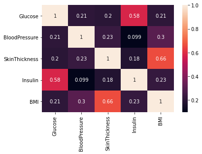

```python
#The correlation with individual pair of attributes:
#diabetesE4['Glucose'].corr(diabetesE4['Insulin'])

#The Correlations Matrix:
sb.heatmap(diabetesE4.corr(), annot = True)
diabetesE4.corr()
```

Statistical Interpretetion: The covariance of the attributes Glucose, BloodPressure, Glucose and SkinThickness are positive which are directly proportional to each other. The correlation value between the attributes describes us the relationship between those attributes. There is positive linear corellation between the attributes. This suggests that the attributes are linearly related. The attributes with strongest correlation are SkinThickness and BMI with correlation 0.66 while on the other hand, the weakest correlation is between Insulin and BloodPressure which is 0.099.

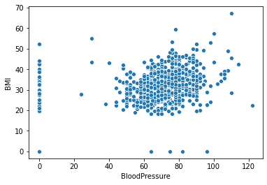

```python
#Creating the scatterplot for the attributes 3 and 6.
sb.scatterplot(data = diabetes.iloc[:,[2,5]], x='BloodPressure', y="BMI")
```

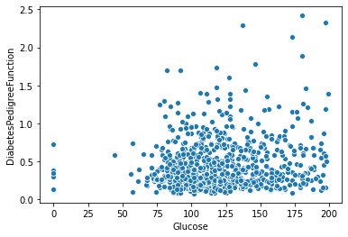

```python
#Creating the scatterplot for the attributes 2 and 7.
sb.scatterplot(data = diabetes.iloc[:,[1, 6]], x='Glucose', y="DiabetesPedigreeFunction")
```

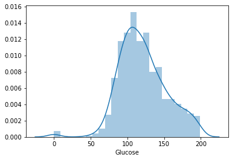

```python
#Histogram for attribute 2.
sb.distplot(diabetes['Glucose'])
```

Intrepretation: The Histogram is unimodal with the normal distribution. The data is not actually very skewed. The peak is at when the glucose value is arounf 100.

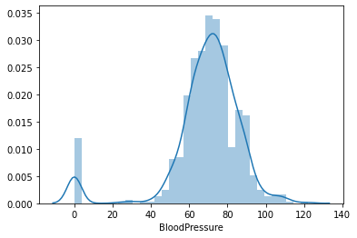

```python
#Histogram for attribute 3.
sb.distplot(diabetes['BloodPressure'])
```

Intrepretation: The Histogram is unimodal with the normal distribution. There is not much skewness in the hsitogram

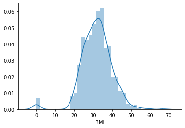

```python
#Histogram for attribute 6.
sb.distplot(diabetes['BMI'])
```

Interpretation: The histogram is unimodal and its not unifrom since it has the peak at the middle part.

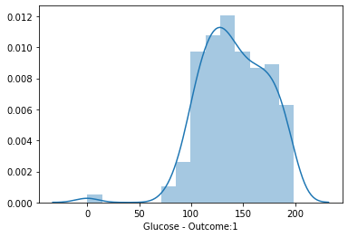

```python
#Selecting the Glucose data with the outcome value 1 and making histogram.
GlucoseDF = diabetes['Glucose']
Goutcome1 = GlucoseDF[diabetes['Outcome'] == 1]
sb.distplot(Goutcome1, axlabel = 'Glucose - Outcome:1')
```

Intrepretation: The historam is slightly left skewed and there is not really peak because the value is almost alwyas the greatest which implies the people with more glucose are more likely to have diabetes.

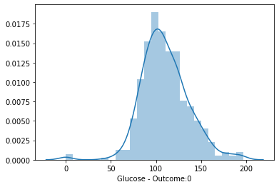

```python
#Selecting the Glucose data with the outcome value 0 and making histogram.
GlucoseDF = diabetes['Glucose']
Goutcome0 = GlucoseDF[diabetes['Outcome'] == 0]
sb.distplot(Goutcome0, axlabel = 'Glucose - Outcome:0')
```

The histogram is normally distributed with the peak being at aroung 100 of the glucose level.

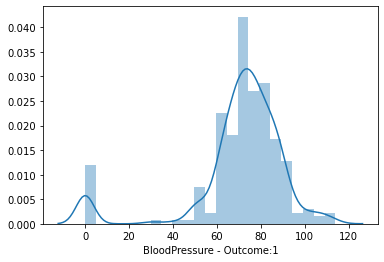

```python
#Selecting the BloodPressure data with the outcome value 1 and making histogram.
BloodPressureDF = diabetes['BloodPressure']
BPoutcome1 = BloodPressureDF[diabetes['Outcome'] == 1]
sb.distplot(BPoutcome1, axlabel = 'BloodPressure - Outcome:1')
```

Interpretation: The histogram explains the people who are predicted to have the diabetes with the help of blood pressure. The histogram is not really skewed and is normally distriuted.

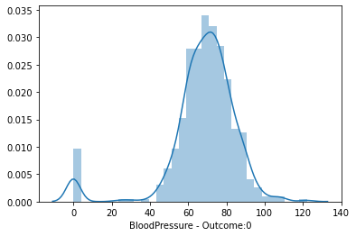

```python
#Selecting the BloodPressure data with the outcome value 0 and making histogram.
BloodPressureDF = diabetes['BloodPressure']
BPoutcome0 = BloodPressureDF[diabetes['Outcome'] == 0]
sb.distplot(BPoutcome0, axlabel = 'BloodPressure - Outcome:0')
```

Interpretation: The histogram explains the people who are predicted to not having the diabetes using the blood pressure. The histogram is not really skewed and the peak is at arounf when the BP is 60 - 80.

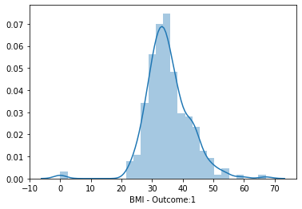

```python
#Selecting the BMI data with the outcome value 1 and making histogram.
BMIDF = diabetes['BMI']
BMIoutcome1 = BMIDF[diabetes['Outcome'] == 1]
sb.distplot(BMIoutcome1, axlabel = 'BMI - Outcome:1')
```

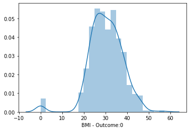

```python
#Selecting the BMI data with the outcome value 0 and making histogram.
BMIDF = diabetes['BMI']
BMIoutcome0 = BMIDF[diabetes['Outcome'] == 0]
sb.distplot(BMIoutcome0, axlabel = 'BMI - Outcome:0')
```

Intrepretation: The histogram is not really skewed and its not really much different when wht Outcome is 1, incase of the BMI.

```python
#Selecting the attributes 2, 7, 8 and removing the 0 that don't make sense.
diabetesE7 = diabetes.iloc[:,[1, 6, 7]]
diabetesE7 = diabetesE7[(diabetesE7 != 0).all(1)]

diabetesE7
```

|  | Glucose | DiabetesPedigreeFunction | Age |
| --- | --- | --- | --- |
| 0 | 148 | 0.627 | 50 |
| 1 | 85 | 0.351 | 31 |
| 2 | 183 | 0.672 | 32 |
| 3 | 89 | 0.167 | 21 |
| 4 | 137 | 2.288 | 33 |
| ... | ... | ... | ... |
| 763 | 101 | 0.171 | 63 |
| 764 | 122 | 0.340 | 27 |
| 765 | 121 | 0.245 | 30 |
| 766 | 126 | 0.349 | 47 |
| 767 | 93 | 0.315 | 23 |

763 rows × 3 columns

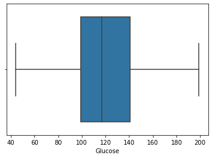

```python
#Making the booxplot for Glucose
sb.boxplot(diabetesE7['Glucose'])
```

Interpretation: The box plot is at aorund the center and there are not the outliner. This is not really very skewed.

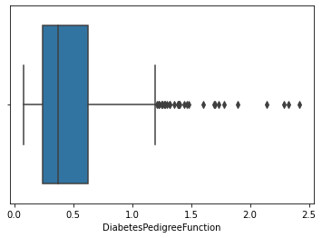

```python
#Making the booxplot for DiabetesPedigreeFunction
sb.boxplot(diabetesE7['DiabetesPedigreeFunction'])
```

Interpretation: The boxplot is right skewed with the outliners being from 1.2 - 2.5.

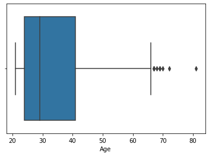

```python
#Making the booxplot for Age
sb.boxplot(diabetesE7['Age'])
```

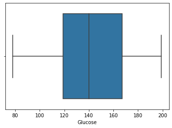

```python
#Selecting the Glucose data with the outcome value 1 and making boxplot.
GlucoseDF = diabetesE7['Glucose']
Goutcome1 = GlucoseDF[diabetes['Outcome'] == 1]
sb.boxplot(Goutcome1)
```

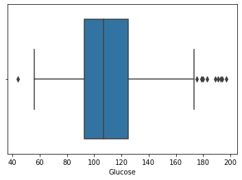

```python
#Selecting the Glucose data with the outcome value 0 and making boxplot.
GlucoseDF = diabetesE7['Glucose']
Goutcome0 = GlucoseDF[diabetes['Outcome'] == 0]
sb.boxplot(Goutcome0)
```

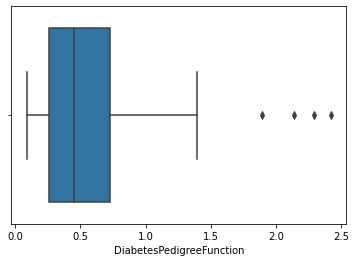

```python
#Selecting the DiabetesPedigreeFunction data with the outcome value 1 and making boxplot.
DiabetesPedigreeFunctionDF = diabetesE7['DiabetesPedigreeFunction']
DPFoutcome1 = DiabetesPedigreeFunctionDF[diabetes['Outcome'] == 1]
sb.boxplot(DPFoutcome1)
```

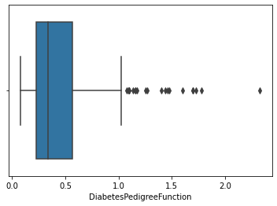

```python
#Selecting the DiabetesPedigreeFunction data with the outcome value 0 and making boxplot.
DiabetesPedigreeFunctionDF = diabetesE7['DiabetesPedigreeFunction']
DPFoutcome0 = DiabetesPedigreeFunctionDF[diabetes['Outcome'] == 0]
sb.boxplot(DPFoutcome0)
```

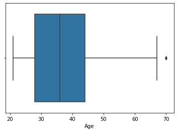

```python
#Selecting the Age data with the outcome value 1 and making boxplot.
AgeDF = diabetesE7['Age']
Ageoutcome1 = AgeDF[diabetes['Outcome'] == 1]
sb.boxplot(Ageoutcome1)
```

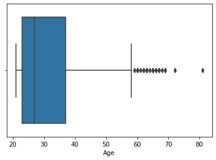

```python
#Selecting the Age data with the outcome value 0 and making boxplot.
AgeDF = diabetesE7['Age']
Ageoutcome0 = AgeDF[diabetes['Outcome'] == 0]
sb.boxplot(Ageoutcome0)
```

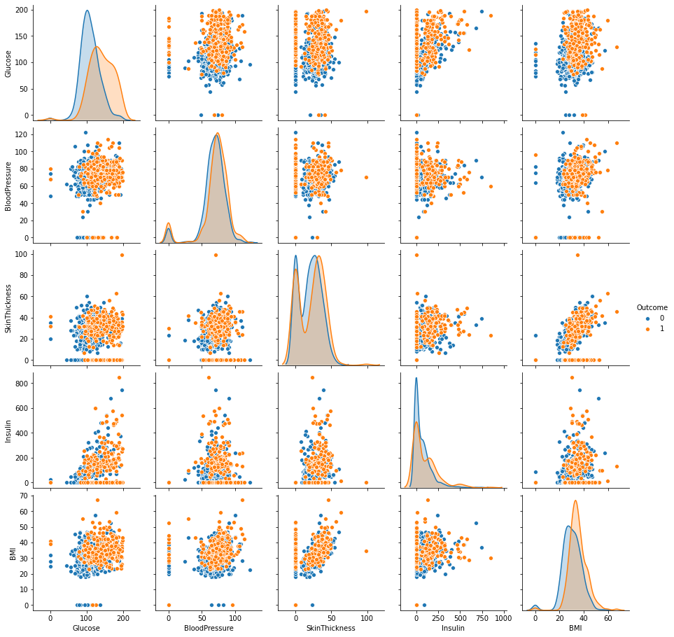

```python
#Selecting the attributes and making the supervised scatterplots using pairplot for all pairs.
sb.pairplot(diabetes, x_vars = ['Glucose', 'BloodPressure', 'SkinThickness', 'Insulin', 'BMI'], y_vars = ['Glucose', 'BloodPressure', 'SkinThickness', 'Insulin', 'BMI'], hue = 'Outcome')

#For individual pair, we can have supervised scatterplot:
#sb.scatterplot(data = diabetes, x = 'Glucose', y = 'BloodPressure', hue = 'Outcome')
```

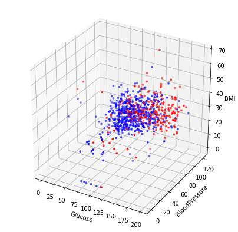

```python
#Doing the 3D scatterplot for the attributes Glucose, BloodPressure, and BMI.
fig = plt.figure(figsize = (7,7))

ax = fig.add_subplot(projection = '3d')
ax.set_xlabel('Glucose')
ax.set_ylabel('BloodPressure')
ax.set_zlabel('BMI ')

#Color: Blue = Outcome - 0, Red = Outcome - 1
ax.scatter(diabetes['Glucose'], diabetes['BloodPressure'], diabetes['BMI'], c = diabetes['Outcome'], cmap = 'bwr', s = 7)
```

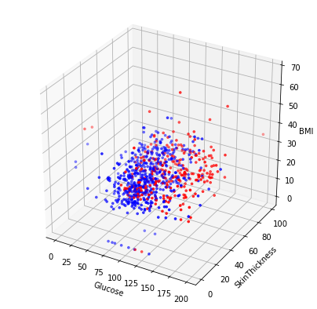

```python
#Doing the 3D scatterplot for the attributes Glucose, SkinThickness, and BMI.
fig = plt.figure(figsize = (7,7))

ax = fig.add_subplot(projection = '3d')
ax.set_xlabel('Glucose')
ax.set_ylabel('SkinThickness')
ax.set_zlabel('BMI ')

#Color: Blue = Outcome - 0, Red = Outcome - 1
ax.scatter(diabetes['Glucose'], diabetes['SkinThickness'], diabetes['BMI'], c = diabetes['Outcome'], cmap = 'bwr', s = 7)
```

```python
#Feeding the .csv data into python and storing it into a variable.
diabetes_cleaned = pd.read_csv('diabetes_cleaned.csv')
diabetes_cleaned
```

|  | 6 | 148 | 72 | 35 | 156 | 33.6 | 0.627 | 50 | 1 |
| --- | --- | --- | --- | --- | --- | --- | --- | --- | --- |
| 0 | 1 | 85 | 66 | 29 | 156 | 26.6 | 0.351 | 31 | 0 |
| 1 | 8 | 183 | 64 | 29 | 156 | 23.3 | 0.672 | 32 | 1 |
| 2 | 1 | 89 | 66 | 23 | 94 | 28.1 | 0.167 | 21 | 0 |
| 3 | 0 | 137 | 40 | 35 | 168 | 43.1 | 2.288 | 33 | 1 |
| 4 | 5 | 116 | 74 | 29 | 156 | 25.6 | 0.201 | 30 | 0 |
| ... | ... | ... | ... | ... | ... | ... | ... | ... | ... |
| 762 | 10 | 101 | 76 | 48 | 180 | 32.9 | 0.171 | 63 | 0 |
| 763 | 2 | 122 | 70 | 27 | 156 | 36.8 | 0.340 | 27 | 0 |
| 764 | 5 | 121 | 72 | 23 | 112 | 26.2 | 0.245 | 30 | 0 |
| 765 | 1 | 126 | 60 | 29 | 156 | 30.1 | 0.349 | 47 | 1 |
| 766 | 1 | 93 | 70 | 31 | 156 | 30.4 | 0.315 | 23 | 0 |

767 rows × 9 columns

Findings: From this introduction, one can learn how to easily clean, preprocess, manipulate, and statistically visualize the availabe dataset with the help of Python. The making of the diagrams like scatterplots, histograms, boxplots, makes it easier for the user to interpret the data and find the conclusion of the project that we are working on accordingly. The use of the modules of the python is also very important since there are many powerfuk tool to use and conclude/predict something in data science.